# Google Analytics Customer Revenue Prediction

La règle des 80/20 s'est avérée vraie pour de nombreuses entreprises - seul un faible pourcentage de clients produit la majeure partie des revenus. Ainsi, les équipes de marketing sont mises au défi de faire les investissements appropriés dans les stratégies promotionnelles. Dans ce problème, nous sommes mis au défi d'analyser un ensemble de données client Google Merchandise Store (également connu sous le nom de GStore, où Google swag est vendu) pour prédire les revenus par client.

L’objectif de ce projet était de prédire la somme des revenues de google par utilisateur.

## Projet réalisé par Adda Simon, Amar Nathan & Amar Ruben

### Data Fields

- fullVisitorId- Identifiant unique pour chaque utilisateur du Google Merchandise Store.
- channelGrouping - Chaîne par laquelle les utilisateurs passent pour accéder au Store.
- date - Date à laquelle l’utilisateur a visité le store.
- device - Spécificités de l’appareil que l’utilisateur a utilisé pour accéder au store.
- geoNetwork - Cette section contient les informations géographiques de l’utilisateur.
- sessionId - Un identifiant unique pour cette visite.
- socialEngagementType - Type d’engagement, que ce soit un “engagé socialement” ou “Pas engagé socialement”.
- totals - Cette section contient les valeurs agrégées de la session.
- trafficSource - Cette section contient des informations sur la source de trafic à l'origine de la session.
- visitId -Un identifiant pour cette session. Cela fait partie de la valeur généralement stockée en tant que cookie.
- visitNumber - Numéro de session de cet utilisateur. S'il s'agit de la première session, celle-ci est définie sur 1.
- visitStartTime - timestamp

### Import libraries

```python
import os
import pandas as pd
import numpy as np
import json
import matplotlib.pyplot as plt
import datetime as datetime
from datetime import timedelta, date
import seaborn as sns
import matplotlib.cm as CM
from pandas.io.json import json_normalize
from plotly.offline import init_notebook_mode, iplot
import plotly.graph_objs as go
from plotly import tools
import lightgbm as lgb
from sklearn import preprocessing
from sklearn.metrics import mean_squared_error
from sklearn.model_selection import GridSearchCV, train_test_split
%matplotlib inline
import math
from xgboost import XGBRegressor
from sklearn.ensemble import RandomForestRegressor
from sklearn.linear_model import LinearRegression
import lightgbm as lgb
from sklearn.model_selection import train_test_split
import seaborn as sns
from matplotlib import pyplot as plt
```

```python
def load_df(path):
    df = pd.read_csv(path, dtype={'fullVisitorId': 'str'})
    json_columns = ['totals','trafficSource','device','geoNetwork']
    for json_col in json_columns:
        in_df = pd.DataFrame(df.pop(json_col).apply(pd.io.json.loads).values.tolist(), index=df.index)
        df = df.join(in_df)

    #json columns of columns
    in_df = pd.DataFrame(df.pop('adwordsClickInfo').values.tolist(), index=df.index)
    df = df.join(in_df)
    return df
```

## Importation et analyse du train

```python
train = load_df("train.csv")
```

```python
train.shape
```

```
(903653, 56)
```

```python
train.columns
```

```
Index(['channelGrouping', 'date', 'fullVisitorId', 'sessionId',
       'socialEngagementType', 'visitId', 'visitNumber', 'visitStartTime',
       'visits', 'hits', 'pageviews', 'bounces', 'newVisits',
       'transactionRevenue', 'campaign', 'source', 'medium', 'keyword',
       'isTrueDirect', 'referralPath', 'adContent', 'campaignCode', 'browser',
       'browserVersion', 'browserSize', 'operatingSystem',
       'operatingSystemVersion', 'isMobile', 'mobileDeviceBranding',
       'mobileDeviceModel', 'mobileInputSelector', 'mobileDeviceInfo',
       'mobileDeviceMarketingName', 'flashVersion', 'language', 'screenColors',
       'screenResolution', 'deviceCategory', 'continent', 'subContinent',
       'country', 'region', 'metro', 'city', 'cityId', 'networkDomain',
       'latitude', 'longitude', 'networkLocation', 'criteriaParameters',
       'page', 'slot', 'gclId', 'adNetworkType', 'isVideoAd',
       'targetingCriteria'],
      dtype='object')
```

```python
train.head()
```

|  | channelGrouping | date | fullVisitorId | sessionId | socialEngagementType | visitId | visitNumber | visitStartTime | visits | hits | ... | latitude | longitude | networkLocation | criteriaParameters | page | slot | gclId | adNetworkType | isVideoAd | targetingCriteria |
| --- | --- | --- | --- | --- | --- | --- | --- | --- | --- | --- | --- | --- | --- | --- | --- | --- | --- | --- | --- | --- | --- |
| 0 | Organic Search | 20160902 | 1131660440785968503 | 1131660440785968503_1472830385 | Not Socially Engaged | 1472830385 | 1 | 1472830385 | 1 | 1 | ... | not available in demo dataset | not available in demo dataset | not available in demo dataset | not available in demo dataset | NaN | NaN | NaN | NaN | NaN | NaN |
| 1 | Organic Search | 20160902 | 377306020877927890 | 377306020877927890_1472880147 | Not Socially Engaged | 1472880147 | 1 | 1472880147 | 1 | 1 | ... | not available in demo dataset | not available in demo dataset | not available in demo dataset | not available in demo dataset | NaN | NaN | NaN | NaN | NaN | NaN |
| 2 | Organic Search | 20160902 | 3895546263509774583 | 3895546263509774583_1472865386 | Not Socially Engaged | 1472865386 | 1 | 1472865386 | 1 | 1 | ... | not available in demo dataset | not available in demo dataset | not available in demo dataset | not available in demo dataset | NaN | NaN | NaN | NaN | NaN | NaN |
| 3 | Organic Search | 20160902 | 4763447161404445595 | 4763447161404445595_1472881213 | Not Socially Engaged | 1472881213 | 1 | 1472881213 | 1 | 1 | ... | not available in demo dataset | not available in demo dataset | not available in demo dataset | not available in demo dataset | NaN | NaN | NaN | NaN | NaN | NaN |
| 4 | Organic Search | 20160902 | 27294437909732085 | 27294437909732085_1472822600 | Not Socially Engaged | 1472822600 | 2 | 1472822600 | 1 | 1 | ... | not available in demo dataset | not available in demo dataset | not available in demo dataset | not available in demo dataset | NaN | NaN | NaN | NaN | NaN | NaN |

5 rows × 56 columns

```python
print(train.info())
```

```
<class 'pandas.core.frame.DataFrame'>
RangeIndex: 903653 entries, 0 to 903652
Data columns (total 56 columns):
channelGrouping              903653 non-null object
date                         903653 non-null int64
fullVisitorId                903653 non-null object
sessionId                    903653 non-null object
socialEngagementType         903653 non-null object
visitId                      903653 non-null int64
visitNumber                  903653 non-null int64
visitStartTime               903653 non-null int64
visits                       903653 non-null object
hits                         903653 non-null object
pageviews                    903553 non-null object
bounces                      450630 non-null object
newVisits                    703060 non-null object
transactionRevenue           11515 non-null object
campaign                     903653 non-null object
source                       903653 non-null object
medium                       903653 non-null object
keyword                      400724 non-null object
isTrueDirect                 274005 non-null object
referralPath                 330941 non-null object
adContent                    10946 non-null object
campaignCode                 1 non-null object
browser                      903653 non-null object
browserVersion               903653 non-null object
browserSize                  903653 non-null object
operatingSystem              903653 non-null object
operatingSystemVersion       903653 non-null object
isMobile                     903653 non-null bool
mobileDeviceBranding         903653 non-null object
mobileDeviceModel            903653 non-null object
mobileInputSelector          903653 non-null object
mobileDeviceInfo             903653 non-null object
mobileDeviceMarketingName    903653 non-null object
flashVersion                 903653 non-null object
language                     903653 non-null object
screenColors                 903653 non-null object
screenResolution             903653 non-null object
deviceCategory               903653 non-null object
continent                    903653 non-null object
subContinent                 903653 non-null object
country                      903653 non-null object
region                       903653 non-null object
metro                        903653 non-null object
city                         903653 non-null object
cityId                       903653 non-null object
networkDomain                903653 non-null object
latitude                     903653 non-null object
longitude                    903653 non-null object
networkLocation              903653 non-null object
criteriaParameters           903653 non-null object
page                         21460 non-null object
slot                         21460 non-null object
gclId                        21561 non-null object
adNetworkType                21460 non-null object
isVideoAd                    21460 non-null object
targetingCriteria            1460 non-null object
dtypes: bool(1), int64(4), object(51)
memory usage: 380.0+ MB
None
```

## Analyse et importation du test

```python
test = load_df("test.csv")
```

```python
test.shape
```

```
(804684, 54)
```

```python
test.columns
```

```
Index(['channelGrouping', 'date', 'fullVisitorId', 'sessionId',
       'socialEngagementType', 'visitId', 'visitNumber', 'visitStartTime',
       'visits', 'hits', 'pageviews', 'newVisits', 'bounces', 'campaign',
       'source', 'medium', 'keyword', 'isTrueDirect', 'referralPath',
       'adContent', 'browser', 'browserVersion', 'browserSize',
       'operatingSystem', 'operatingSystemVersion', 'isMobile',
       'mobileDeviceBranding', 'mobileDeviceModel', 'mobileInputSelector',
       'mobileDeviceInfo', 'mobileDeviceMarketingName', 'flashVersion',
       'language', 'screenColors', 'screenResolution', 'deviceCategory',
       'continent', 'subContinent', 'country', 'region', 'metro', 'city',
       'cityId', 'networkDomain', 'latitude', 'longitude', 'networkLocation',
       'criteriaParameters', 'page', 'slot', 'gclId', 'adNetworkType',
       'isVideoAd', 'targetingCriteria'],
      dtype='object')
```

```python
print(test.info())
```

```
<class 'pandas.core.frame.DataFrame'>
RangeIndex: 804684 entries, 0 to 804683
Data columns (total 54 columns):
channelGrouping              804684 non-null object
date                         804684 non-null int64
fullVisitorId                804684 non-null object
sessionId                    804684 non-null object
socialEngagementType         804684 non-null object
visitId                      804684 non-null int64
visitNumber                  804684 non-null int64
visitStartTime               804684 non-null int64
visits                       804684 non-null object
hits                         804684 non-null object
pageviews                    804545 non-null object
newVisits                    604370 non-null object
bounces                      420948 non-null object
campaign                     804684 non-null object
source                       804684 non-null object
medium                       804684 non-null object
keyword                      413652 non-null object
isTrueDirect                 260513 non-null object
referralPath                 235323 non-null object
adContent                    53791 non-null object
browser                      804684 non-null object
browserVersion               804684 non-null object
browserSize                  804684 non-null object
operatingSystem              804684 non-null object
operatingSystemVersion       804684 non-null object
isMobile                     804684 non-null bool
mobileDeviceBranding         804684 non-null object
mobileDeviceModel            804684 non-null object
mobileInputSelector          804684 non-null object
mobileDeviceInfo             804684 non-null object
mobileDeviceMarketingName    804684 non-null object
flashVersion                 804684 non-null object
language                     804684 non-null object
screenColors                 804684 non-null object
screenResolution             804684 non-null object
deviceCategory               804684 non-null object
continent                    804684 non-null object
subContinent                 804684 non-null object
country                      804684 non-null object
region                       804684 non-null object
metro                        804684 non-null object
city                         804684 non-null object
cityId                       804684 non-null object
networkDomain                804684 non-null object
latitude                     804684 non-null object
longitude                    804684 non-null object
networkLocation              804684 non-null object
criteriaParameters           804684 non-null object
page                         53814 non-null object
slot                         53814 non-null object
gclId                        53862 non-null object
adNetworkType                53814 non-null object
isVideoAd                    53814 non-null object
targetingCriteria            1845 non-null object
dtypes: bool(1), int64(4), object(49)
memory usage: 326.1+ MB
None
```

```python
test.head()
```

|  | channelGrouping | date | fullVisitorId | sessionId | socialEngagementType | visitId | visitNumber | visitStartTime | visits | hits | ... | latitude | longitude | networkLocation | criteriaParameters | page | slot | gclId | adNetworkType | isVideoAd | targetingCriteria |
| --- | --- | --- | --- | --- | --- | --- | --- | --- | --- | --- | --- | --- | --- | --- | --- | --- | --- | --- | --- | --- | --- |
| 0 | Organic Search | 20171016 | 6167871330617112363 | 6167871330617112363_1508151024 | Not Socially Engaged | 1508151024 | 2 | 1508151024 | 1 | 4 | ... | not available in demo dataset | not available in demo dataset | not available in demo dataset | not available in demo dataset | NaN | NaN | NaN | NaN | NaN | NaN |
| 1 | Organic Search | 20171016 | 0643697640977915618 | 0643697640977915618_1508175522 | Not Socially Engaged | 1508175522 | 1 | 1508175522 | 1 | 5 | ... | not available in demo dataset | not available in demo dataset | not available in demo dataset | not available in demo dataset | NaN | NaN | NaN | NaN | NaN | NaN |
| 2 | Organic Search | 20171016 | 6059383810968229466 | 6059383810968229466_1508143220 | Not Socially Engaged | 1508143220 | 1 | 1508143220 | 1 | 7 | ... | not available in demo dataset | not available in demo dataset | not available in demo dataset | not available in demo dataset | NaN | NaN | NaN | NaN | NaN | NaN |
| 3 | Organic Search | 20171016 | 2376720078563423631 | 2376720078563423631_1508193530 | Not Socially Engaged | 1508193530 | 1 | 1508193530 | 1 | 8 | ... | not available in demo dataset | not available in demo dataset | not available in demo dataset | not available in demo dataset | NaN | NaN | NaN | NaN | NaN | NaN |
| 4 | Organic Search | 20171016 | 2314544520795440038 | 2314544520795440038_1508217442 | Not Socially Engaged | 1508217442 | 1 | 1508217442 | 1 | 9 | ... | not available in demo dataset | not available in demo dataset | not available in demo dataset | not available in demo dataset | NaN | NaN | NaN | NaN | NaN | NaN |

5 rows × 54 columns

Comme on l'a vu avec le head il semble il y avoir bcp de NA, il serait interessant de savoir ou et combien

```python
train.isna().sum()
```

```
channelGrouping                   0
date                              0
fullVisitorId                     0
sessionId                         0
socialEngagementType              0
visitId                           0
visitNumber                       0
visitStartTime                    0
visits                            0
hits                              0
pageviews                       100
bounces                      453023
newVisits                    200593
transactionRevenue           892138
campaign                          0
source                            0
medium                            0
keyword                      502929
isTrueDirect                 629648
referralPath                 572712
adContent                    892707
campaignCode                 903652
browser                           0
browserVersion                    0
browserSize                       0
operatingSystem                   0
operatingSystemVersion            0
isMobile                          0
mobileDeviceBranding              0
mobileDeviceModel                 0
mobileInputSelector               0
mobileDeviceInfo                  0
mobileDeviceMarketingName         0
flashVersion                      0
language                          0
screenColors                      0
screenResolution                  0
deviceCategory                    0
continent                         0
subContinent                      0
country                           0
region                            0
metro                             0
city                              0
cityId                            0
networkDomain                     0
latitude                          0
longitude                         0
networkLocation                   0
criteriaParameters                0
page                         882193
slot                         882193
gclId                        882092
adNetworkType                882193
isVideoAd                    882193
targetingCriteria            902193
dtype: int64
```

**Faisons un plot en pourcentage répresentant combien et ou il y a des NA**

```python
miss_per = {}
for k, v in dict(train.isna().sum(axis=0)).items():
    if v == 0:
        continue
    miss_per[k] = 100 * float(v) / len(train)

import operator
sorted_x = sorted(miss_per.items(), key=operator.itemgetter(1), reverse=True)
print ("Il y a " + str(len(miss_per)) + " colonnes avec des valeurs manquantes")

kys = [_[0] for _ in sorted_x][::-1]
vls = [_[1] for _ in sorted_x][::-1]
trace1 = go.Bar(y = kys, orientation="h" , x = vls, marker=dict(color="#d6a5ff"))
layout = go.Layout(title="Pourcentage de valeur manquante",
                   xaxis=dict(title="Pourcentage"),
                   height=400, margin=dict(l=300, r=300))
figure = go.Figure(data = [trace1], layout = layout)
iplot(figure)
```

```
Il y a 15 colonnes avec des valeurs manquantes
```

[interactive chart not shown]

Remplacons tout les champs vide avec des NaN

```python
train.replace('(not set)', np.nan)
train.replace("not available in demo dataset", np.nan)
train.replace('(not provided)', np.nan)
train.replace('unknown.unknown', np.nan)
train.replace('(none)', np.nan)
train.replace('/', np.nan)
train.replace('Not Socially Engaged', np.nan)
test.replace('(not set)', np.nan)
test.replace("not available in demo dataset", np.nan)
test.replace('(not provided)', np.nan)
test.replace('unknown.unknown', np.nan)
test.replace('(none)', np.nan)
test.replace('/', np.nan)
test.replace('Not Socially Engaged', np.nan)
```

|  | channelGrouping | date | fullVisitorId | sessionId | socialEngagementType | visitId | visitNumber | visitStartTime | visits | hits | ... | latitude | longitude | networkLocation | criteriaParameters | page | slot | gclId | adNetworkType | isVideoAd | targetingCriteria |
| --- | --- | --- | --- | --- | --- | --- | --- | --- | --- | --- | --- | --- | --- | --- | --- | --- | --- | --- | --- | --- | --- |
| 0 | Organic Search | 20171016 | 6167871330617112363 | 6167871330617112363_1508151024 | NaN | 1508151024 | 2 | 1508151024 | 1 | 4 | ... | not available in demo dataset | not available in demo dataset | not available in demo dataset | not available in demo dataset | NaN | NaN | NaN | NaN | NaN | NaN |
| 1 | Organic Search | 20171016 | 0643697640977915618 | 0643697640977915618_1508175522 | NaN | 1508175522 | 1 | 1508175522 | 1 | 5 | ... | not available in demo dataset | not available in demo dataset | not available in demo dataset | not available in demo dataset | NaN | NaN | NaN | NaN | NaN | NaN |
| 2 | Organic Search | 20171016 | 6059383810968229466 | 6059383810968229466_1508143220 | NaN | 1508143220 | 1 | 1508143220 | 1 | 7 | ... | not available in demo dataset | not available in demo dataset | not available in demo dataset | not available in demo dataset | NaN | NaN | NaN | NaN | NaN | NaN |
| 3 | Organic Search | 20171016 | 2376720078563423631 | 2376720078563423631_1508193530 | NaN | 1508193530 | 1 | 1508193530 | 1 | 8 | ... | not available in demo dataset | not available in demo dataset | not available in demo dataset | not available in demo dataset | NaN | NaN | NaN | NaN | NaN | NaN |
| 4 | Organic Search | 20171016 | 2314544520795440038 | 2314544520795440038_1508217442 | NaN | 1508217442 | 1 | 1508217442 | 1 | 9 | ... | not available in demo dataset | not available in demo dataset | not available in demo dataset | not available in demo dataset | NaN | NaN | NaN | NaN | NaN | NaN |
| ... | ... | ... | ... | ... | ... | ... | ... | ... | ... | ... | ... | ... | ... | ... | ... | ... | ... | ... | ... | ... | ... |
| 804679 | Social | 20180421 | 9084225574121020383 | 9084225574121020383_1524358436 | NaN | 1524358436 | 2 | 1524358436 | 1 | 33 | ... | not available in demo dataset | not available in demo dataset | not available in demo dataset | not available in demo dataset | NaN | NaN | NaN | NaN | NaN | NaN |
| 804680 | Social | 20180421 | 6146210385566305056 | 6146210385566305056_1524317728 | NaN | 1524317728 | 1 | 1524317728 | 1 | 36 | ... | not available in demo dataset | not available in demo dataset | not available in demo dataset | not available in demo dataset | NaN | NaN | NaN | NaN | NaN | NaN |
| 804681 | Social | 20180421 | 7484543584006767361 | 7484543584006767361_1524364725 | NaN | 1524364725 | 1 | 1524364725 | 1 | 53 | ... | not available in demo dataset | not available in demo dataset | not available in demo dataset | not available in demo dataset | NaN | NaN | NaN | NaN | NaN | NaN |
| 804682 | Social | 20180421 | 2915966035609674201 | 2915966035609674201_1524330416 | NaN | 1524330416 | 1 | 1524330416 | 1 | 58 | ... | not available in demo dataset | not available in demo dataset | not available in demo dataset | not available in demo dataset | NaN | NaN | NaN | NaN | NaN | NaN |
| 804683 | Social | 20180421 | 5334918847827785763 | 5334918847827785763_1524301572 | NaN | 1524301572 | 1 | 1524301572 | 1 | 71 | ... | not available in demo dataset | not available in demo dataset | not available in demo dataset | not available in demo dataset | NaN | NaN | NaN | NaN | NaN | NaN |

804684 rows × 54 columns

Jetons un oeil au variable numeric du train et test set

- train

```python
numeric_features_train = train.select_dtypes(include=[np.number])
numeric_features_train.columns
```

```
Index(['date', 'visitId', 'visitNumber', 'visitStartTime'], dtype='object')
```

- test

```python
numeric_features_test = test.select_dtypes(include=[np.number])
numeric_features_test.columns
```

```
Index(['date', 'visitId', 'visitNumber', 'visitStartTime'], dtype='object')
```

Jetons un oeil au variable catégorielle du train et test set

- train

```python
categorical_features_train = train.select_dtypes(include=[np.object])
categorical_features_train.columns
```

```
Index(['channelGrouping', 'fullVisitorId', 'sessionId', 'socialEngagementType',
       'visits', 'hits', 'pageviews', 'bounces', 'newVisits',
       'transactionRevenue', 'campaign', 'source', 'medium', 'keyword',
       'isTrueDirect', 'referralPath', 'adContent', 'campaignCode', 'browser',
       'browserVersion', 'browserSize', 'operatingSystem',
       'operatingSystemVersion', 'mobileDeviceBranding', 'mobileDeviceModel',
       'mobileInputSelector', 'mobileDeviceInfo', 'mobileDeviceMarketingName',
       'flashVersion', 'language', 'screenColors', 'screenResolution',
       'deviceCategory', 'continent', 'subContinent', 'country', 'region',
       'metro', 'city', 'cityId', 'networkDomain', 'latitude', 'longitude',
       'networkLocation', 'criteriaParameters', 'page', 'slot', 'gclId',
       'adNetworkType', 'isVideoAd', 'targetingCriteria'],
      dtype='object')
```

- test

```python
categorical_features_test = test.select_dtypes(include=[np.object])
categorical_features_test.columns
```

```
Index(['channelGrouping', 'fullVisitorId', 'sessionId', 'socialEngagementType',
       'visits', 'hits', 'pageviews', 'newVisits', 'bounces', 'campaign',
       'source', 'medium', 'keyword', 'isTrueDirect', 'referralPath',
       'adContent', 'browser', 'browserVersion', 'browserSize',
       'operatingSystem', 'operatingSystemVersion', 'mobileDeviceBranding',
       'mobileDeviceModel', 'mobileInputSelector', 'mobileDeviceInfo',
       'mobileDeviceMarketingName', 'flashVersion', 'language', 'screenColors',
       'screenResolution', 'deviceCategory', 'continent', 'subContinent',
       'country', 'region', 'metro', 'city', 'cityId', 'networkDomain',
       'latitude', 'longitude', 'networkLocation', 'criteriaParameters',
       'page', 'slot', 'gclId', 'adNetworkType', 'isVideoAd',
       'targetingCriteria'],
      dtype='object')
```

## Exploration des données et Analyses (EDA)

```python
train.columns
```

```
Index(['channelGrouping', 'date', 'fullVisitorId', 'sessionId',
       'socialEngagementType', 'visitId', 'visitNumber', 'visitStartTime',
       'visits', 'hits', 'pageviews', 'bounces', 'newVisits',
       'transactionRevenue', 'campaign', 'source', 'medium', 'keyword',
       'isTrueDirect', 'referralPath', 'adContent', 'campaignCode', 'browser',
       'browserVersion', 'browserSize', 'operatingSystem',
       'operatingSystemVersion', 'isMobile', 'mobileDeviceBranding',
       'mobileDeviceModel', 'mobileInputSelector', 'mobileDeviceInfo',
       'mobileDeviceMarketingName', 'flashVersion', 'language', 'screenColors',
       'screenResolution', 'deviceCategory', 'continent', 'subContinent',
       'country', 'region', 'metro', 'city', 'cityId', 'networkDomain',
       'latitude', 'longitude', 'networkLocation', 'criteriaParameters',
       'page', 'slot', 'gclId', 'adNetworkType', 'isVideoAd',
       'targetingCriteria'],
      dtype='object')
```

```python
device_cols = ["browser", "deviceCategory", "operatingSystem"]

colors = ["#d6a5ff", "#fca6da", "#f4d39c", "#a9fcca"]
traces = []
for i, col in enumerate(device_cols):
    t = train[col].value_counts()
    traces.append(go.Bar(marker=dict(color=colors[i]),orientation="h", y = t.index[:15][::-1], x = t.values[:15][::-1]))

fig = tools.make_subplots(rows=1, cols=3, subplot_titles=["Visites: Categorie", "Visites: Navigateur","Visites: OS"], print_grid=False)
fig.append_trace(traces[1], 1, 1)
fig.append_trace(traces[0], 1, 2)
fig.append_trace(traces[2], 1, 3)

fig['layout'].update(height=400, showlegend=False, title="Visites par attributs de périphérique")
iplot(fig)

## convert transaction revenue to float
train["transactionRevenue"] = train["transactionRevenue"].astype('float')

device_cols = ["browser", "deviceCategory", "operatingSystem"]

fig = tools.make_subplots(rows=1, cols=3, subplot_titles=["Revenu moyen: Categorie", "Revenu moyen: Navigateur","Revenu moyen: OS"], print_grid=False)

colors = ["red", "green", "purple"]
trs = []
for i, col in enumerate(device_cols):
    tmp = train.groupby(col).agg({"transactionRevenue": "mean"}).reset_index().rename(columns={"transactionRevenue" : "Mean Revenue"})
    tmp = tmp.dropna().sort_values("Mean Revenue", ascending = False)
    tr = go.Bar(x = tmp["Mean Revenue"][::-1], orientation="h", marker=dict(opacity=0.5, color=colors[i]), y = tmp[col][::-1])
    trs.append(tr)

fig.append_trace(trs[1], 1, 1)
fig.append_trace(trs[0], 1, 2)
fig.append_trace(trs[2], 1, 3)
fig['layout'].update(height=400, showlegend=False, title="Revenu moyen par attribut d'appareil")
iplot(fig)
```

[interactive chart not shown]

Il y a une différence significative dans les visites depuis les mobiles et les tablettes, mais les revenus moyens pour les deux sont très proches. Il est intéressant de noter que le nombre maximal de visites provient du navigateur Chrome, mais que les revenus maximaux sont collectés grâce aux visites via Firefox. Les utilisateurs de Chrome OS ont généré des revenus maximaux, bien que le nombre maximal de visites proviennent d'utilisateurs Windows et Macintosh.

### Geo Network Attributes:

Voyons quels sont tous les attributs de geoNetwork.

Analysons la répartition des utilisateurs sur 5 continents.

```python
train.columns
```

```
Index(['channelGrouping', 'date', 'fullVisitorId', 'sessionId',
       'socialEngagementType', 'visitId', 'visitNumber', 'visitStartTime',
       'visits', 'hits', 'pageviews', 'bounces', 'newVisits',
       'transactionRevenue', 'campaign', 'source', 'medium', 'keyword',
       'isTrueDirect', 'referralPath', 'adContent', 'campaignCode', 'browser',
       'browserVersion', 'browserSize', 'operatingSystem',
       'operatingSystemVersion', 'isMobile', 'mobileDeviceBranding',
       'mobileDeviceModel', 'mobileInputSelector', 'mobileDeviceInfo',
       'mobileDeviceMarketingName', 'flashVersion', 'language', 'screenColors',
       'screenResolution', 'deviceCategory', 'continent', 'subContinent',
       'country', 'region', 'metro', 'city', 'cityId', 'networkDomain',
       'latitude', 'longitude', 'networkLocation', 'criteriaParameters',
       'page', 'slot', 'gclId', 'adNetworkType', 'isVideoAd',
       'targetingCriteria'],
      dtype='object')
```

```python
geo_cols = ['city', 'continent','country',
            'metro', 'networkDomain', 'region','subContinent']
geo_cols = ['continent','subContinent']

colors = ["#d6a5ff", "#fca6da"]
fig = tools.make_subplots(rows=1, cols=2, subplot_titles=["Visites : GeoNetwork Continent", "Visites : GeoNetwork subContinent"], print_grid=False)
trs = []
for i,col in enumerate(geo_cols):
    t = train[col].value_counts()
    tr = go.Bar(x = t.index[:20], marker=dict(color=colors[i]), y = t.values[:20])
    trs.append(tr)

fig.append_trace(trs[0], 1, 1)
fig.append_trace(trs[1], 1, 2)
fig['layout'].update(height=400, margin=dict(b=150), showlegend=False)
iplot(fig)




geo_cols = ['continent','subContinent']
fig = tools.make_subplots(rows=1, cols=2, subplot_titles=["Revenu moyen: Continent", "Revenu moyen: SubContinent"], print_grid=False)

colors = ["blue", "orange"]
trs = []
for i, col in enumerate(geo_cols):
    tmp = train.groupby(col).agg({"transactionRevenue": "mean"}).reset_index().rename(columns={"transactionRevenue" : "Mean Revenue"})
    tmp = tmp.dropna().sort_values("Mean Revenue", ascending = False)
    tr = go.Bar(y = tmp["Mean Revenue"], orientation="v", marker=dict(opacity=0.5, color=colors[i]), x= tmp[col])
    trs.append(tr)

fig.append_trace(trs[0], 1, 1)
fig.append_trace(trs[1], 1, 2)
fig['layout'].update(height=450, margin=dict(b=200), showlegend=False)
iplot(fig)
```

[interactive chart not shown]

On peut voir avec une meilleur visualisation

```python
colorscale = [[0, 'rgb(102,194,165)'], [0.0005, 'rgb(102,194,165)'],
              [0.01, 'rgb(171,221,164)'], [0.02, 'rgb(230,245,152)'],
              [0.04, 'rgb(255,255,191)'], [0.05, 'rgb(254,224,139)'],
              [0.10, 'rgb(253,174,97)'], [0.25, 'rgb(213,62,79)'], [1.0, 'rgb(158,1,66)']]

data = [ dict(
        type = 'choropleth',
        autocolorscale = False,
        colorscale = colorscale,
        showscale = True,
        locations = train["country"].value_counts().index,
        locationmode = 'country names',
        z = train["country"].value_counts().values,
        marker = dict(
            line = dict(color = 'rgb(250,250,225)', width = 1)),
            colorbar = dict( title = 'Customer Visits ')
            )
       ]

layout = dict(
    height=600,
    title = 'Distribution mondiale des visites clients',
    geo = dict(
        showframe = True,
        showocean = True,
        oceancolor = 'rgb(28,107,160)',
        projection = dict(
        type = 'orthographic',
            rotation = dict(
                    lon = 50,
                    lat = 10),
        ),
        lonaxis =  dict(
                showgrid = True,
                gridcolor = 'rgb(12, 102, 102)'
            ),
        lataxis = dict(
                showgrid = True,
                gridcolor = 'rgb(12, 102, 102)'
                )
            ),
        )
fig = dict(data=data, layout=layout)
iplot(fig)
```

[interactive chart not shown]

On peut voir sur le graph que les plus grandes visites se font aux USA

### Channel grouping

#### Channel: The channel via which the user came to the Store.

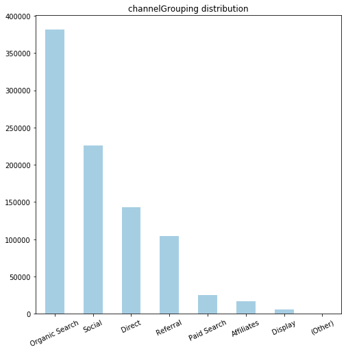

```python
train.channelGrouping.value_counts().plot(kind="bar",title="channelGrouping distribution",figsize=(8,8),rot=25,colormap='Paired')
```

```python
tmp = train["channelGrouping"].value_counts()
colors = ["#8d44fc", "#ed95d5", "#caadf7", "#6161b7", "#7e7eba", "#babad1"]
trace = go.Pie(labels=tmp.index, values=tmp.values, marker=dict(colors=colors))
layout = go.Layout(title="Channel Grouping", height=400)
fig = go.Figure(data = [trace], layout = layout)
iplot(fig, filename='basic_pie_chart')
```

[interactive chart not shown]

#### Convert date to year, month and day

```python
train['date'] = pd.to_datetime((train['date']).astype(str), format = '%Y-%m-%d')
train[['year', 'month', 'day']] = train['date'].astype(str).str.split('-', expand = True)
train.drop('date', axis =1,inplace = True)
```

```python
test['date'] = pd.to_datetime((test['date']).astype(str), format = '%Y-%m-%d')
test[['year', 'month', 'day']] = test['date'].astype(str).str.split('-', expand = True)
test.drop('date', axis =1,inplace = True)
```

```python
fig = tools.make_subplots(rows=1, cols=3, subplot_titles=["Visites par mois", "Visites par jour du mois"], print_grid=False)
trs = []
for i,col in enumerate(["month", "day"]):
    t = train[col].value_counts()
    tr = go.Bar(x = t.index, marker=dict(color=colors[i]), y = t.values)
    trs.append(tr)

fig.append_trace(trs[0], 1, 1)
fig.append_trace(trs[1], 1, 2)
fig['layout'].update(height=400, showlegend=False)
iplot(fig)



tmp1 = train.groupby('month').agg({"transactionRevenue" : "mean"}).reset_index()
tmp2 = train.groupby('day').agg({"transactionRevenue" : "mean"}).reset_index()

fig = tools.make_subplots(rows=1, cols=3, subplot_titles=["Revenu moyen par mois", "Revenu moyen par jour du mois"], print_grid=False)
tr1 = go.Bar(x = tmp1.month, marker=dict(color="red", opacity=0.5), y = tmp1.transactionRevenue)
tr2 = go.Bar(x = tmp2.day, marker=dict(color="orange", opacity=0.5), y = tmp2.transactionRevenue)
fig.append_trace(tr1, 1, 1)
fig.append_trace(tr2, 1, 2)
fig['layout'].update(height=400, showlegend=False)
iplot(fig)
```

[interactive chart not shown]

#### Fréquence des visites

```python
vn = train["visitNumber"].value_counts()
def vn_bins(x):
    if x == 1:
        return "1"
    elif x < 5:
        return "2-5"
    elif x < 10:
        return "5-10"
    elif x < 50:
        return "10-50"
    elif x < 100:
        return "50-100"
    else:
        return "100+"

vn = train["visitNumber"].apply(vn_bins).value_counts()

trace1 = go.Bar(y = vn.index[::-1], orientation="h" , x = vn.values[::-1], marker=dict(color="#7af9ad"))
layout = go.Layout(title="Distribution du nombre de visites",
                   xaxis=dict(title="Frequence"),yaxis=dict(title="Nombre de visites") ,
                   height=400, margin=dict(l=300, r=300))
figure = go.Figure(data = [trace1], layout = layout)
iplot(figure)
```

[interactive chart not shown]

```
Il y a  11515 visiteurs du train dataset ayant des revenus de transaction totaux non nuls
```

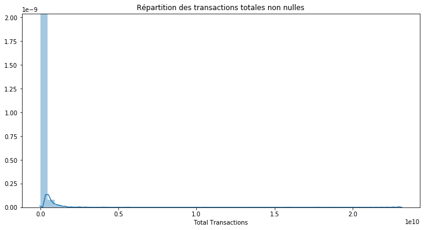

```python
non_zero = train[train["transactionRevenue"] > 0]["transactionRevenue"]
print ("Il y a  " + str(len(non_zero)) + " visiteurs du train dataset ayant des revenus de transaction totaux non nuls")

plt.figure(figsize=(12,6))
sns.distplot(non_zero)
plt.title("Répartition des transactions totales non nulles");
plt.xlabel("Total Transactions");
```

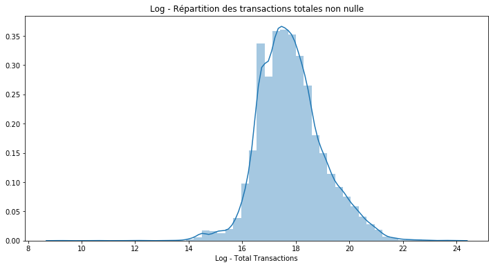

```python
plt.figure(figsize=(12,6))
sns.distplot(np.log1p(non_zero))
plt.title("Log - Répartition des transactions totales non nulle");
plt.xlabel("Log - Total Transactions");
```

# Attributs du profil d'un visiteur

```python
import warnings
warnings.simplefilter(action='ignore', category=FutureWarning)

agg_dict = {}
for col in ["bounces", "hits", "newVisits", "pageviews", "transactionRevenue"]:
    train[col] = train[col].astype('float')
    agg_dict[col] = "sum"
tmp = train.groupby("fullVisitorId").agg(agg_dict).reset_index()
tmp.head()
```

|  | fullVisitorId | bounces | hits | newVisits | pageviews | transactionRevenue |
| --- | --- | --- | --- | --- | --- | --- |
| 0 | 0000010278554503158 | 0.0 | 11.0 | 1.0 | 8.0 | 0.0 |
| 1 | 0000020424342248747 | 0.0 | 17.0 | 1.0 | 13.0 | 0.0 |
| 2 | 0000027376579751715 | 0.0 | 6.0 | 1.0 | 5.0 | 0.0 |
| 3 | 0000039460501403861 | 0.0 | 2.0 | 1.0 | 2.0 | 0.0 |
| 4 | 0000040862739425590 | 0.0 | 5.0 | 1.0 | 5.0 | 0.0 |

```python
train.columns
```

```
Index(['channelGrouping', 'fullVisitorId', 'sessionId', 'socialEngagementType',
       'visitId', 'visitNumber', 'visitStartTime', 'visits', 'hits',
       'pageviews', 'bounces', 'newVisits', 'transactionRevenue', 'campaign',
       'source', 'medium', 'keyword', 'isTrueDirect', 'referralPath',
       'adContent', 'campaignCode', 'browser', 'browserVersion', 'browserSize',
       'operatingSystem', 'operatingSystemVersion', 'isMobile',
       'mobileDeviceBranding', 'mobileDeviceModel', 'mobileInputSelector',
       'mobileDeviceInfo', 'mobileDeviceMarketingName', 'flashVersion',
       'language', 'screenColors', 'screenResolution', 'deviceCategory',
       'continent', 'subContinent', 'country', 'region', 'metro', 'city',
       'cityId', 'networkDomain', 'latitude', 'longitude', 'networkLocation',
       'criteriaParameters', 'page', 'slot', 'gclId', 'adNetworkType',
       'isVideoAd', 'targetingCriteria', 'year', 'month', 'day'],
      dtype='object')
```

```python
def getbin_hits(x):
    if x < 5:
        return "1-5"
    elif x < 10:
        return "5-10"
    elif x < 30:
        return "10-30"
    elif x < 50:
        return "30-50"
    elif x < 100:
        return "50-100"
    else:
        return "100+"


#["bounces", "hits", "newVisits", "pageviews", "transactionRevenue"]:


tmp["total_hits_bin"] = tmp["hits"].apply(getbin_hits)
tmp["totals_bounces_bin"] = tmp["bounces"].apply(lambda x : str(x) if x <= 5 else "5+")
tmp["totals_pageviews_bin"] = tmp["pageviews"].apply(lambda x : str(x) if x <= 50 else "50+")

t1 = tmp["total_hits_bin"].value_counts()
t2 = tmp["totals_bounces_bin"].value_counts()
t3 = tmp["newVisits"].value_counts()
t4 = tmp["totals_pageviews_bin"].value_counts()

fig = tools.make_subplots(rows=2, cols=2, subplot_titles=["Nombre total de visites par utilisateur", "Total de rebonds par utilisateur",
                                                         "Nombre total de NewVistits par utilisateur", "Nombre total de pages vues par utilisateur"], print_grid=False)

tr1 = go.Bar(x = t1.index[:20], y = t1.values[:20])
tr2 = go.Bar(x = t2.index[:20], y = t2.values[:20])
tr3 = go.Bar(x = t3.index[:20], y = t3.values[:20])
tr4 = go.Bar(x = t4.index, y = t4.values)

fig.append_trace(tr1, 1, 1)
fig.append_trace(tr2, 1, 2)
fig.append_trace(tr3, 2, 1)
fig.append_trace(tr4, 2, 2)

fig['layout'].update(height=700, showlegend=False)
iplot(fig)
```

[interactive chart not shown]

## Model

Identifions quelles colonnes peuvent être supprimées.

- Supression des colonnes avec des valeurs nulles
- Suppression des identifiants et autres colonnes non pertinentes

#### Supression de toutes les colonnes qui ont toutes les valeurs nulles

```python
train.dropna(axis=1, how='all')
```

|  | channelGrouping | fullVisitorId | sessionId | socialEngagementType | visitId | visitNumber | visitStartTime | visits | hits | pageviews | ... | criteriaParameters | page | slot | gclId | adNetworkType | isVideoAd | targetingCriteria | year | month | day |
| --- | --- | --- | --- | --- | --- | --- | --- | --- | --- | --- | --- | --- | --- | --- | --- | --- | --- | --- | --- | --- | --- |
| 0 | Organic Search | 1131660440785968503 | 1131660440785968503_1472830385 | Not Socially Engaged | 1472830385 | 1 | 1472830385 | 1 | 1.0 | 1.0 | ... | not available in demo dataset | NaN | NaN | NaN | NaN | NaN | NaN | 2016 | 09 | 02 |
| 1 | Organic Search | 377306020877927890 | 377306020877927890_1472880147 | Not Socially Engaged | 1472880147 | 1 | 1472880147 | 1 | 1.0 | 1.0 | ... | not available in demo dataset | NaN | NaN | NaN | NaN | NaN | NaN | 2016 | 09 | 02 |
| 2 | Organic Search | 3895546263509774583 | 3895546263509774583_1472865386 | Not Socially Engaged | 1472865386 | 1 | 1472865386 | 1 | 1.0 | 1.0 | ... | not available in demo dataset | NaN | NaN | NaN | NaN | NaN | NaN | 2016 | 09 | 02 |
| 3 | Organic Search | 4763447161404445595 | 4763447161404445595_1472881213 | Not Socially Engaged | 1472881213 | 1 | 1472881213 | 1 | 1.0 | 1.0 | ... | not available in demo dataset | NaN | NaN | NaN | NaN | NaN | NaN | 2016 | 09 | 02 |
| 4 | Organic Search | 27294437909732085 | 27294437909732085_1472822600 | Not Socially Engaged | 1472822600 | 2 | 1472822600 | 1 | 1.0 | 1.0 | ... | not available in demo dataset | NaN | NaN | NaN | NaN | NaN | NaN | 2016 | 09 | 02 |
| ... | ... | ... | ... | ... | ... | ... | ... | ... | ... | ... | ... | ... | ... | ... | ... | ... | ... | ... | ... | ... | ... |
| 903648 | Social | 5123779100307500332 | 5123779100307500332_1483554750 | Not Socially Engaged | 1483554750 | 1 | 1483554750 | 1 | 17.0 | 15.0 | ... | not available in demo dataset | NaN | NaN | NaN | NaN | NaN | NaN | 2017 | 01 | 04 |
| 903649 | Social | 7231728964973959842 | 7231728964973959842_1483543798 | Not Socially Engaged | 1483543798 | 1 | 1483543798 | 1 | 18.0 | 13.0 | ... | not available in demo dataset | NaN | NaN | NaN | NaN | NaN | NaN | 2017 | 01 | 04 |
| 903650 | Social | 5744576632396406899 | 5744576632396406899_1483526434 | Not Socially Engaged | 1483526434 | 1 | 1483526434 | 1 | 24.0 | 21.0 | ... | not available in demo dataset | NaN | NaN | NaN | NaN | NaN | NaN | 2017 | 01 | 04 |
| 903651 | Social | 2709355455991750775 | 2709355455991750775_1483592857 | Not Socially Engaged | 1483592857 | 1 | 1483592864 | 1 | 24.0 | 22.0 | ... | not available in demo dataset | NaN | NaN | NaN | NaN | NaN | NaN | 2017 | 01 | 04 |
| 903652 | Social | 0814900163617805053 | 0814900163617805053_1483574474 | Not Socially Engaged | 1483574474 | 1 | 1483574474 | 1 | 31.0 | 31.0 | ... | not available in demo dataset | NaN | NaN | NaN | NaN | NaN | NaN | 2017 | 01 | 04 |

903653 rows × 58 columns

```python
test.dropna(axis=1, how='all')
```

|  | channelGrouping | fullVisitorId | sessionId | socialEngagementType | visitId | visitNumber | visitStartTime | visits | hits | pageviews | ... | criteriaParameters | page | slot | gclId | adNetworkType | isVideoAd | targetingCriteria | year | month | day |
| --- | --- | --- | --- | --- | --- | --- | --- | --- | --- | --- | --- | --- | --- | --- | --- | --- | --- | --- | --- | --- | --- |
| 0 | Organic Search | 6167871330617112363 | 6167871330617112363_1508151024 | Not Socially Engaged | 1508151024 | 2 | 1508151024 | 1 | 4 | 4 | ... | not available in demo dataset | NaN | NaN | NaN | NaN | NaN | NaN | 2017 | 10 | 16 |
| 1 | Organic Search | 0643697640977915618 | 0643697640977915618_1508175522 | Not Socially Engaged | 1508175522 | 1 | 1508175522 | 1 | 5 | 5 | ... | not available in demo dataset | NaN | NaN | NaN | NaN | NaN | NaN | 2017 | 10 | 16 |
| 2 | Organic Search | 6059383810968229466 | 6059383810968229466_1508143220 | Not Socially Engaged | 1508143220 | 1 | 1508143220 | 1 | 7 | 7 | ... | not available in demo dataset | NaN | NaN | NaN | NaN | NaN | NaN | 2017 | 10 | 16 |
| 3 | Organic Search | 2376720078563423631 | 2376720078563423631_1508193530 | Not Socially Engaged | 1508193530 | 1 | 1508193530 | 1 | 8 | 4 | ... | not available in demo dataset | NaN | NaN | NaN | NaN | NaN | NaN | 2017 | 10 | 16 |
| 4 | Organic Search | 2314544520795440038 | 2314544520795440038_1508217442 | Not Socially Engaged | 1508217442 | 1 | 1508217442 | 1 | 9 | 4 | ... | not available in demo dataset | NaN | NaN | NaN | NaN | NaN | NaN | 2017 | 10 | 16 |
| ... | ... | ... | ... | ... | ... | ... | ... | ... | ... | ... | ... | ... | ... | ... | ... | ... | ... | ... | ... | ... | ... |
| 804679 | Social | 9084225574121020383 | 9084225574121020383_1524358436 | Not Socially Engaged | 1524358436 | 2 | 1524358436 | 1 | 33 | 26 | ... | not available in demo dataset | NaN | NaN | NaN | NaN | NaN | NaN | 2018 | 04 | 21 |
| 804680 | Social | 6146210385566305056 | 6146210385566305056_1524317728 | Not Socially Engaged | 1524317728 | 1 | 1524317728 | 1 | 36 | 34 | ... | not available in demo dataset | NaN | NaN | NaN | NaN | NaN | NaN | 2018 | 04 | 21 |
| 804681 | Social | 7484543584006767361 | 7484543584006767361_1524364725 | Not Socially Engaged | 1524364725 | 1 | 1524364725 | 1 | 53 | 35 | ... | not available in demo dataset | NaN | NaN | NaN | NaN | NaN | NaN | 2018 | 04 | 21 |
| 804682 | Social | 2915966035609674201 | 2915966035609674201_1524330416 | Not Socially Engaged | 1524330416 | 1 | 1524330416 | 1 | 58 | 34 | ... | not available in demo dataset | NaN | NaN | NaN | NaN | NaN | NaN | 2018 | 04 | 21 |
| 804683 | Social | 5334918847827785763 | 5334918847827785763_1524301572 | Not Socially Engaged | 1524301572 | 1 | 1524301572 | 1 | 71 | 38 | ... | not available in demo dataset | NaN | NaN | NaN | NaN | NaN | NaN | 2018 | 04 | 21 |

804684 rows × 56 columns

```python
#les hits et les pages vues sont les seules valeurs numériques, convertissons-les en objet numpy
train["hits"].fillna(0, inplace=True)
train["hits"] = train["hits"].astype('float')
train["pageviews"].fillna(0, inplace=True)
train["pageviews"] = train["pageviews"].astype('float')
```

```python
test["hits"].fillna(0, inplace=True)
test["hits"] = train["hits"].astype('float')
test["pageviews"].fillna(0, inplace=True)
test["pageviews"] = train["pageviews"].astype('float')
```

```python
train.shape,test.shape
```

```
((903653, 58), (804684, 56))
```

Application du natural log sur transactionRevenue ce qui donne transactionRevenue_log

```python
train["transactionRevenue"].fillna(0, inplace=True)
train["transactionRevenue"] = train["transactionRevenue"].astype('float')
train['transactionRevenue_log'] = np.log(train[train['transactionRevenue'] > 0]["transactionRevenue"] + 0.01)
```

##### Copions le dataframe dans des dataframes temporaires pour construire notre modele

```python
train_dataset = train.copy()
test_dataset = test.copy()
```

### Variable à predire

```python
y = train_dataset['transactionRevenue_log'].fillna(0)
y.head(5)
```

```
0    0.0
1    0.0
2    0.0
3    0.0
4    0.0
Name: transactionRevenue_log, dtype: float64
```

```python
y.sample(10)
```

```
868777    0.0
454009    0.0
18425     0.0
1045      0.0
768403    0.0
462508    0.0
11102     0.0
3384      0.0
636865    0.0
17820     0.0
Name: transactionRevenue_log, dtype: float64
```

Suppression des colonnes qui n'aident pas au training

```python
train_dataset.drop('fullVisitorId', axis=1, inplace=True)
train_dataset.drop('sessionId', axis=1, inplace=True)
train_dataset.drop('transactionRevenue', axis=1, inplace=True)
train_dataset.drop('visitId', axis=1, inplace=True)
train_dataset.drop('visitStartTime', axis=1, inplace=True)
train_dataset.drop('transactionRevenue_log', axis=1, inplace=True)
train_dataset.drop('visits', axis=1, inplace=True)
train_dataset.drop('visitNumber', axis=1, inplace=True)
train_dataset.drop('isTrueDirect', axis=1, inplace=True)
train_dataset.drop('adContent', axis=1, inplace=True)
train_dataset.drop('networkDomain', axis=1, inplace=True)
train_dataset.drop('isVideoAd', axis=1, inplace=True)
train_dataset.drop('gclId', axis=1, inplace=True)
train_dataset.drop('slot', axis=1, inplace=True)
train_dataset.drop('adNetworkType', axis=1, inplace=True)
train_dataset.drop('keyword', axis=1, inplace=True)
train_dataset.drop('referralPath', axis=1, inplace=True)
train_dataset.drop('page', axis=1, inplace=True)
train_dataset.drop('campaignCode', axis=1, inplace=True)
train_dataset.drop('newVisits', axis=1, inplace=True)
train_dataset.drop('bounces', axis=1, inplace=True)
train_dataset.drop('targetingCriteria', axis=1, inplace=True)
train_dataset.drop('socialEngagementType', axis=1, inplace=True)
train_dataset.drop('browserSize', axis=1, inplace=True)
train_dataset.drop('browserVersion', axis=1, inplace=True)
train_dataset.drop('flashVersion', axis=1, inplace=True)
train_dataset.drop('language', axis=1, inplace=True)
train_dataset.drop('mobileDeviceBranding', axis=1, inplace=True)
train_dataset.drop('mobileDeviceInfo', axis=1, inplace=True)
train_dataset.drop('mobileDeviceMarketingName', axis=1, inplace=True)
train_dataset.drop('mobileDeviceModel', axis=1, inplace=True)
train_dataset.drop('mobileInputSelector', axis=1, inplace=True)
train_dataset.drop('operatingSystemVersion', axis=1, inplace=True)
train_dataset.drop('screenColors', axis=1, inplace=True)
train_dataset.drop('screenResolution', axis=1, inplace=True)
train_dataset.drop('cityId', axis=1, inplace=True)
train_dataset.drop('longitude', axis=1, inplace=True)
train_dataset.drop('latitude', axis=1, inplace=True)
train_dataset.drop('networkLocation', axis=1, inplace=True)
train_dataset.drop('criteriaParameters', axis=1, inplace=True)
```

```python
train_dataset.head(5)
```

|  | channelGrouping | hits | pageviews | campaign | source | medium | browser | operatingSystem | isMobile | deviceCategory | continent | subContinent | country | region | metro | city | year | month | day |
| --- | --- | --- | --- | --- | --- | --- | --- | --- | --- | --- | --- | --- | --- | --- | --- | --- | --- | --- | --- |
| 0 | Organic Search | 1.0 | 1.0 | (not set) | google | organic | Chrome | Windows | False | desktop | Asia | Western Asia | Turkey | Izmir | (not set) | Izmir | 2016 | 09 | 02 |
| 1 | Organic Search | 1.0 | 1.0 | (not set) | google | organic | Firefox | Macintosh | False | desktop | Oceania | Australasia | Australia | not available in demo dataset | not available in demo dataset | not available in demo dataset | 2016 | 09 | 02 |
| 2 | Organic Search | 1.0 | 1.0 | (not set) | google | organic | Chrome | Windows | False | desktop | Europe | Southern Europe | Spain | Community of Madrid | (not set) | Madrid | 2016 | 09 | 02 |
| 3 | Organic Search | 1.0 | 1.0 | (not set) | google | organic | UC Browser | Linux | False | desktop | Asia | Southeast Asia | Indonesia | not available in demo dataset | not available in demo dataset | not available in demo dataset | 2016 | 09 | 02 |
| 4 | Organic Search | 1.0 | 1.0 | (not set) | google | organic | Chrome | Android | True | mobile | Europe | Northern Europe | United Kingdom | not available in demo dataset | not available in demo dataset | not available in demo dataset | 2016 | 09 | 02 |

```python
train_dataset.shape
```

```
(903653, 19)
```

Suppression des colonnes qui n'aident pas au test

```python
test_dataset.drop('fullVisitorId', axis=1, inplace=True)
test_dataset.drop('sessionId', axis=1, inplace=True)
test_dataset.drop('visitId', axis=1, inplace=True)
test_dataset.drop('visitStartTime', axis=1, inplace=True)
test_dataset.drop('visits', axis=1, inplace=True)
test_dataset.drop('visitNumber', axis=1, inplace=True)
test_dataset.drop('isTrueDirect', axis=1, inplace=True)
test_dataset.drop('adContent', axis=1, inplace=True)
test_dataset.drop('networkDomain', axis=1, inplace=True)
test_dataset.drop('isVideoAd', axis=1, inplace=True)
test_dataset.drop('gclId', axis=1, inplace=True)
test_dataset.drop('slot', axis=1, inplace=True)
test_dataset.drop('adNetworkType', axis=1, inplace=True)
test_dataset.drop('keyword', axis=1, inplace=True)
test_dataset.drop('referralPath', axis=1, inplace=True)
test_dataset.drop('page', axis=1, inplace=True)
test_dataset.drop('newVisits', axis=1, inplace=True)
test_dataset.drop('bounces', axis=1, inplace=True)
test_dataset.drop('targetingCriteria', axis=1, inplace=True)
test_dataset.drop('socialEngagementType', axis=1, inplace=True)
test_dataset.drop('browserSize', axis=1, inplace=True)
test_dataset.drop('browserVersion', axis=1, inplace=True)
test_dataset.drop('flashVersion', axis=1, inplace=True)
test_dataset.drop('language', axis=1, inplace=True)
test_dataset.drop('mobileDeviceBranding', axis=1, inplace=True)
test_dataset.drop('mobileDeviceInfo', axis=1, inplace=True)
test_dataset.drop('mobileDeviceMarketingName', axis=1, inplace=True)
test_dataset.drop('mobileDeviceModel', axis=1, inplace=True)
test_dataset.drop('mobileInputSelector', axis=1, inplace=True)
test_dataset.drop('operatingSystemVersion', axis=1, inplace=True)
test_dataset.drop('screenColors', axis=1, inplace=True)
test_dataset.drop('screenResolution', axis=1, inplace=True)
test_dataset.drop('cityId', axis=1, inplace=True)
test_dataset.drop('longitude', axis=1, inplace=True)
test_dataset.drop('latitude', axis=1, inplace=True)
test_dataset.drop('networkLocation', axis=1, inplace=True)
test_dataset.drop('criteriaParameters', axis=1, inplace=True)
```

```python
test_dataset.head(5)
```

|  | channelGrouping | hits | pageviews | campaign | source | medium | browser | operatingSystem | isMobile | deviceCategory | continent | subContinent | country | region | metro | city | year | month | day |
| --- | --- | --- | --- | --- | --- | --- | --- | --- | --- | --- | --- | --- | --- | --- | --- | --- | --- | --- | --- |
| 0 | Organic Search | 1.0 | 1.0 | (not set) | google | organic | Chrome | Macintosh | False | desktop | Asia | Southeast Asia | Singapore | (not set) | (not set) | (not set) | 2017 | 10 | 16 |
| 1 | Organic Search | 1.0 | 1.0 | (not set) | google | organic | Chrome | Windows | False | desktop | Europe | Southern Europe | Spain | Aragon | (not set) | Zaragoza | 2017 | 10 | 16 |
| 2 | Organic Search | 1.0 | 1.0 | (not set) | google | organic | Chrome | Macintosh | False | desktop | Europe | Western Europe | France | not available in demo dataset | not available in demo dataset | not available in demo dataset | 2017 | 10 | 16 |
| 3 | Organic Search | 1.0 | 1.0 | (not set) | google | organic | Safari | iOS | True | mobile | Americas | Northern America | United States | California | San Francisco-Oakland-San Jose CA | Mountain View | 2017 | 10 | 16 |
| 4 | Organic Search | 1.0 | 1.0 | (not set) | google | organic | Safari | Macintosh | False | desktop | Americas | Northern America | United States | California | San Francisco-Oakland-San Jose CA | San Jose | 2017 | 10 | 16 |

**Regardons les variables catégorielles que l'on va devoir changer**

```python
categorical_features_train_dataset = train_dataset.select_dtypes(include=[np.object])
categorical_features_train_dataset.columns
```

```
Index(['channelGrouping', 'campaign', 'source', 'medium', 'browser',
       'operatingSystem', 'deviceCategory', 'continent', 'subContinent',
       'country', 'region', 'metro', 'city', 'year', 'month', 'day'],
      dtype='object')
```

## LabelEncoder, OneHotEncoder

*to convert string categorical values to numerical values*

```python
from sklearn.preprocessing import LabelEncoder, OneHotEncoder
labelencoder_X = LabelEncoder()
train_dataset['channelGrouping'] = labelencoder_X.fit_transform(train_dataset['channelGrouping'])
train_dataset['campaign'] = labelencoder_X.fit_transform(train_dataset['campaign'])
train_dataset['medium'] = labelencoder_X.fit_transform(train_dataset['medium'])
train_dataset['source'] = labelencoder_X.fit_transform(train_dataset['source'])
train_dataset['browser'] = labelencoder_X.fit_transform(train_dataset['browser'])
train_dataset['deviceCategory'] = labelencoder_X.fit_transform(train_dataset['deviceCategory'])
train_dataset['isMobile'] = labelencoder_X.fit_transform(train_dataset['isMobile'])
train_dataset['operatingSystem'] = labelencoder_X.fit_transform(train_dataset['operatingSystem'])
train_dataset['city'] = labelencoder_X.fit_transform(train_dataset['city'])
train_dataset['continent'] = labelencoder_X.fit_transform(train_dataset['continent'])
train_dataset['country'] = labelencoder_X.fit_transform(train_dataset['country'])
train_dataset['metro'] = labelencoder_X.fit_transform(train_dataset['metro'])
train_dataset['region'] = labelencoder_X.fit_transform(train_dataset['region'])
train_dataset['subContinent'] = labelencoder_X.fit_transform(train_dataset['subContinent'])
train_dataset['year'] = labelencoder_X.fit_transform(train_dataset['year'])
train_dataset['month'] = labelencoder_X.fit_transform(train_dataset['month'])
train_dataset['day'] = labelencoder_X.fit_transform(train_dataset['day'])
```

```python
train_dataset.head()
```

|  | channelGrouping | hits | pageviews | campaign | source | medium | browser | operatingSystem | isMobile | deviceCategory | continent | subContinent | country | region | metro | city | year | month | day |
| --- | --- | --- | --- | --- | --- | --- | --- | --- | --- | --- | --- | --- | --- | --- | --- | --- | --- | --- | --- |
| 0 | 4 | 1.0 | 1.0 | 0 | 149 | 5 | 11 | 16 | 0 | 0 | 3 | 21 | 204 | 150 | 0 | 258 | 0 | 8 | 1 |
| 1 | 4 | 1.0 | 1.0 | 0 | 149 | 5 | 16 | 7 | 0 | 0 | 5 | 1 | 12 | 375 | 93 | 648 | 0 | 8 | 1 |
| 2 | 4 | 1.0 | 1.0 | 0 | 149 | 5 | 11 | 16 | 0 | 0 | 4 | 19 | 181 | 78 | 0 | 325 | 0 | 8 | 1 |
| 3 | 4 | 1.0 | 1.0 | 0 | 149 | 5 | 46 | 6 | 0 | 0 | 3 | 16 | 94 | 375 | 93 | 648 | 0 | 8 | 1 |
| 4 | 4 | 1.0 | 1.0 | 0 | 149 | 5 | 11 | 1 | 1 | 1 | 4 | 13 | 211 | 375 | 93 | 648 | 0 | 8 | 1 |

```python
test_dataset['channelGrouping'] = labelencoder_X.fit_transform(test_dataset['channelGrouping'])
test_dataset['campaign'] = labelencoder_X.fit_transform(test_dataset['campaign'])
test_dataset['medium'] = labelencoder_X.fit_transform(test_dataset['medium'])
test_dataset['source'] = labelencoder_X.fit_transform(test_dataset['source'])
test_dataset['browser'] = labelencoder_X.fit_transform(test_dataset['browser'])
test_dataset['deviceCategory'] = labelencoder_X.fit_transform(test_dataset['deviceCategory'])
test_dataset['isMobile'] = labelencoder_X.fit_transform(test_dataset['isMobile'])
test_dataset['operatingSystem'] = labelencoder_X.fit_transform(test_dataset['operatingSystem'])
test_dataset['city'] = labelencoder_X.fit_transform(test_dataset['city'])
test_dataset['continent'] = labelencoder_X.fit_transform(test_dataset['continent'])
test_dataset['country'] = labelencoder_X.fit_transform(test_dataset['country'])
test_dataset['metro'] = labelencoder_X.fit_transform(test_dataset['metro'])
test_dataset['region'] = labelencoder_X.fit_transform(test_dataset['region'])
test_dataset['subContinent'] = labelencoder_X.fit_transform(test_dataset['subContinent'])
test_dataset['year'] = labelencoder_X.fit_transform(test_dataset['year'])
test_dataset['month'] = labelencoder_X.fit_transform(test_dataset['month'])
test_dataset['day'] = labelencoder_X.fit_transform(test_dataset['day'])
```

```python
test_dataset.head()
```

|  | channelGrouping | hits | pageviews | campaign | source | medium | browser | operatingSystem | isMobile | deviceCategory | continent | subContinent | country | region | metro | city | year | month | day |
| --- | --- | --- | --- | --- | --- | --- | --- | --- | --- | --- | --- | --- | --- | --- | --- | --- | --- | --- | --- |
| 0 | 4 | 1.0 | 1.0 | 4 | 124 | 5 | 31 | 7 | 0 | 0 | 3 | 16 | 170 | 0 | 0 | 0 | 0 | 6 | 15 |
| 1 | 4 | 1.0 | 1.0 | 4 | 124 | 5 | 31 | 18 | 0 | 0 | 4 | 19 | 179 | 17 | 0 | 726 | 0 | 6 | 15 |
| 2 | 4 | 1.0 | 1.0 | 4 | 124 | 5 | 31 | 7 | 0 | 0 | 4 | 22 | 66 | 375 | 108 | 731 | 0 | 6 | 15 |
| 3 | 4 | 1.0 | 1.0 | 4 | 124 | 5 | 57 | 21 | 1 | 1 | 2 | 12 | 210 | 56 | 92 | 417 | 0 | 6 | 15 |
| 4 | 4 | 1.0 | 1.0 | 4 | 124 | 5 | 57 | 7 | 0 | 0 | 2 | 12 | 210 | 56 | 92 | 580 | 0 | 6 | 15 |

```python
train_dataset.shape, test_dataset.shape
```

```
((903653, 19), (804684, 19))
```

### Heatmap

Let's see correlation

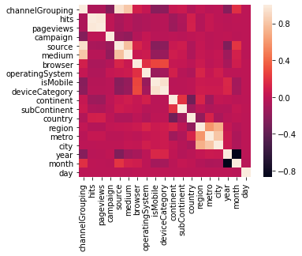

```python
corelation_train = train_dataset.corr()
sns.heatmap(corelation_train, square = True)
```

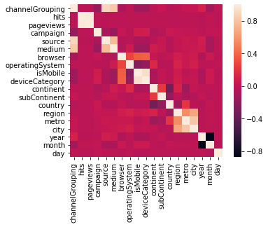

```python
corelation_test = test_dataset.corr()
sns.heatmap(corelation_test, square = True)
```

### Split into train and test

```python
X_train, X_test, Y_train, Y_test = train_test_split(train_dataset ,y, test_size=0.2)
```

### Premier modèle : Linear Regression

```python
lin_reg = LinearRegression()
lin_reg.fit(X_train, Y_train)
```

```
LinearRegression(copy_X=True, fit_intercept=True, n_jobs=None, normalize=False)
```

### Deuxième modèle : XGBRegressor

XGBoost est une bibliothèque optimisée de renforcement de gradient distribué conçue pour être très efficace, flexible et portable. Il implémente des algorithmes d'apprentissage automatique dans le cadre du Gradient Boosting. XGBoost fournit un boosting d'arbre parallèle (également connu sous le nom de GBDT, GBM) qui résout de nombreux problèmes de science des données de manière rapide et précise.

```python
XGB_model = XGBRegressor()
XGB_model.fit(X_train, Y_train, eval_metric='rmse',verbose=130)
```

```
[10:41:59] WARNING: src/objective/regression_obj.cu:152: reg:linear is now deprecated in favor of reg:squarederror.
```

```
XGBRegressor(base_score=0.5, booster='gbtree', colsample_bylevel=1,
             colsample_bynode=1, colsample_bytree=1, gamma=0,
             importance_type='gain', learning_rate=0.1, max_delta_step=0,
             max_depth=3, min_child_weight=1, missing=None, n_estimators=100,
             n_jobs=1, nthread=None, objective='reg:linear', random_state=0,
             reg_alpha=0, reg_lambda=1, scale_pos_weight=1, seed=None,
             silent=None, subsample=1, verbosity=1)
```

### Troisième modèle : Random forest

```python
RF_model = RandomForestRegressor(n_estimators = 100, random_state = 42)
RF_model.fit(X_train, Y_train)
```

```
RandomForestRegressor(bootstrap=True, criterion='mse', max_depth=None,
                      max_features='auto', max_leaf_nodes=None,
                      min_impurity_decrease=0.0, min_impurity_split=None,
                      min_samples_leaf=1, min_samples_split=2,
                      min_weight_fraction_leaf=0.0, n_estimators=100,
                      n_jobs=None, oob_score=False, random_state=42, verbose=0,
                      warm_start=False)
```

### Quatrième modèle : LGBMRegressor

```python
LGB_model = lgb.LGBMRegressor()
LGB_model.fit(X_train, Y_train, eval_metric='rmse', verbose=100)
```

```
LGBMRegressor(boosting_type='gbdt', class_weight=None, colsample_bytree=1.0,
              importance_type='split', learning_rate=0.1, max_depth=-1,
              min_child_samples=20, min_child_weight=0.001, min_split_gain=0.0,
              n_estimators=100, n_jobs=-1, num_leaves=31, objective=None,
              random_state=None, reg_alpha=0.0, reg_lambda=0.0, silent=True,
              subsample=1.0, subsample_for_bin=200000, subsample_freq=0)
```

```python
y_pred_XGB = XGB_model.predict(X_test)
y_pred_LGB = LGB_model.predict(X_test)
y_pred_rf = RF_model.predict(X_test)
y_pred_lr = lin_reg.predict(X_test)
```

Remplacons les valeurs negatives avec 0

```python
y_pred_XGB[y_pred_XGB < 0] =0
y_pred_XGB
y_pred_LGB[y_pred_LGB < 0] =0
y_pred_LGB
y_pred_rf[y_pred_rf < 0] =0
y_pred_rf
y_pred_lr[y_pred_lr < 0] =0
y_pred_lr
```

```
array([0.        , 0.        , 0.39584395, ..., 0.        , 0.        ,
       0.        ])
```

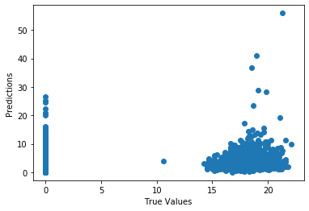

```python
plt.scatter(Y_test, y_pred_lr)
plt.xlabel('True Values')
plt.ylabel('Predictions')
```

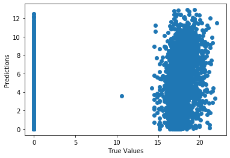

```python
plt.scatter(Y_test, y_pred_XGB)
plt.xlabel('True Values')
plt.ylabel('Predictions')
```

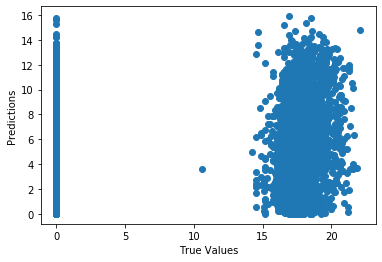

```python
plt.scatter(Y_test, y_pred_LGB)
plt.xlabel('True Values')
plt.ylabel('Predictions')
```

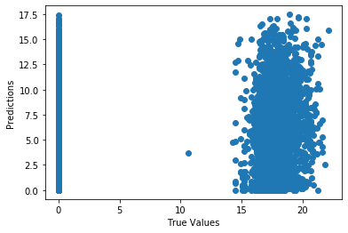

```python
plt.scatter(Y_test, y_pred_rf )
plt.xlabel('True Values')
plt.ylabel('Predictions')
```

## Evaluation des modèles utilisant le root mean squared error

```python
print("LinReg: sqrt  ", math.sqrt(mean_squared_error(Y_test, y_pred_lr)))
print("XGBoost: sqrt  ", math.sqrt(mean_squared_error(Y_test, y_pred_XGB)))
print("LGB: sqrt  ", math.sqrt(mean_squared_error(Y_test, y_pred_LGB)))
print("RandomForest: sqrt  ",math.sqrt(mean_squared_error(Y_test, y_pred_rf) ))
```

```
LinReg: sqrt   1.7860336852422025
XGBoost: sqrt   1.6511185582386303
LGB: sqrt   1.617965145951954
RandomForest: sqrt   1.7152710679514627
```

Prenons donc LGB car c'est lui qui nous donne le plus petit MSE

```python
final_result= LGB_model.predict(test_dataset)
```

```python
final_result.size
```

```
804684
```

Voyons maintenant les caractéristiques importantes du modèle light gbm.

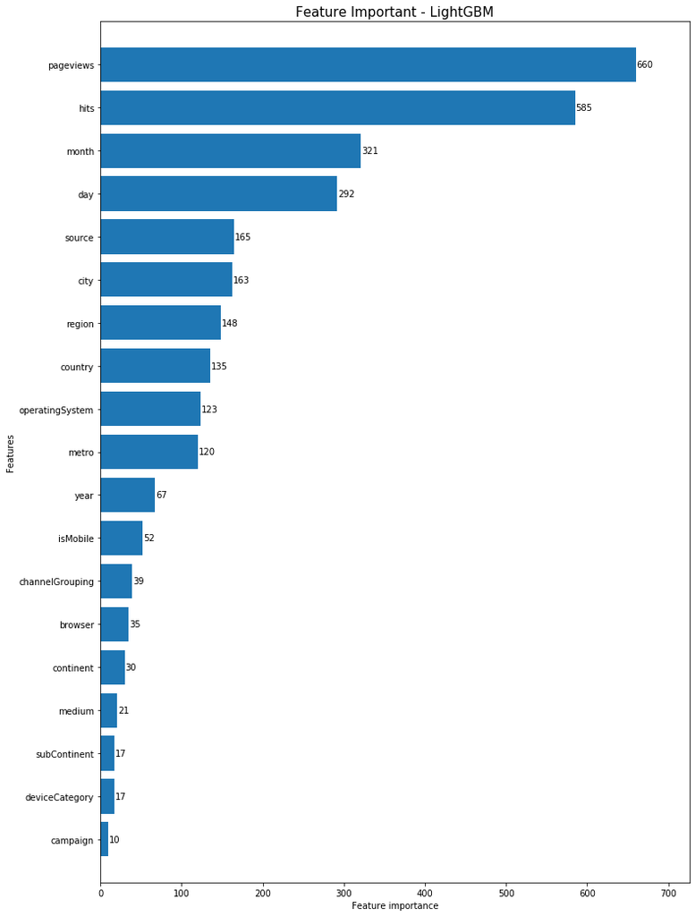

```python
fig, ax = plt.subplots(figsize=(12,18))
lgb.plot_importance(LGB_model, max_num_features=50, height=0.8, ax=ax)
ax.grid(False)
plt.title("Feature Important - LightGBM", fontsize=15)
plt.show()
```

```python
#Définissons toutes les valeurs négatives sur 0
final_result[final_result < 0] =0
final_result
```

```
array([0.00214374, 0.00214374, 0.00214374, ..., 0.0030293 , 0.00144262,
       0.0030293 ])
```

```python
fullVisitorId_1 = test['fullVisitorId']
```

```python
fichier_csv = pd.DataFrame({'fullVisitorId': fullVisitorId_1,'PredictedLogRevenue':final_result},columns=['fullVisitorId','PredictedLogRevenue'])
```

```python
fichier_csv.head(1000)
```

|  | fullVisitorId | PredictedLogRevenue |
| --- | --- | --- |
| 0 | 6167871330617112363 | 0.002144 |
| 1 | 0643697640977915618 | 0.002144 |
| 2 | 6059383810968229466 | 0.002144 |
| 3 | 2376720078563423631 | 0.002656 |
| 4 | 2314544520795440038 | 0.002656 |
| ... | ... | ... |
| 995 | 0623175312365318620 | 1.283019 |
| 996 | 8453237741913312449 | 0.000000 |
| 997 | 1314426348114534975 | 0.000000 |
| 998 | 8855807376521102824 | 0.000000 |
| 999 | 7372459020218964 | 1.674387 |

1000 rows × 2 columns

```python
fichier_csv = fichier_csv.groupby('fullVisitorId').sum().reset_index()
```

```python
fichier_csv.to_csv(r"resultat_final.csv",index=False)
```